# StockMarketEDA

yfinance : A library to download financial market data from Yahoo Finance. This can be used to download stock market data from India as well as other global markets.

```python
pip install yfinance
```

[output not shown]

[output not shown]

Import the libraries

```python
import numpy as np
import pandas as pd
import matplotlib.pyplot as plt
import seaborn as sns
sns.set_style('whitegrid')
%matplotlib inline
import yfinance as yf
```

Download the historical stock data for a specific company listed on the Indian stock market using yfinance library:

```python
stock = 'RELIANCE.NS'
rel_data = yf.download(stock,start = '2022-08-01',end = '2023-01-18')
```

```
[*********************100%***********************]  1 of 1 completed
```

```python
rel_data.head()
```

| Date | Open | High | Low | Close | Adj Close | Volume |
| --- | --- | --- | --- | --- | --- | --- |
| 2022-08-01 00:00:00+05:30 | 2519.149902 | 2587.750000 | 2507.600098 | 2574.850098 | 2567.121094 | 7245568 |
| 2022-08-02 00:00:00+05:30 | 2572.500000 | 2607.800049 | 2561.550049 | 2584.649902 | 2576.891602 | 6423115 |
| 2022-08-03 00:00:00+05:30 | 2600.000000 | 2610.000000 | 2567.449951 | 2606.350098 | 2598.526611 | 6576824 |
| 2022-08-04 00:00:00+05:30 | 2610.000000 | 2617.750000 | 2535.000000 | 2571.899902 | 2564.179932 | 6676577 |
| 2022-08-05 00:00:00+05:30 | 2576.000000 | 2578.800049 | 2526.949951 | 2534.000000 | 2526.393799 | 6434433 |

```python
rel_data.describe()
```

|  | Open | High | Low | Close | Adj Close | Volume |
| --- | --- | --- | --- | --- | --- | --- |
| count | 116.000000 | 116.000000 | 116.000000 | 116.000000 | 116.000000 | 1.160000e+02 |
| mean | 2551.131463 | 2574.439215 | 2527.946135 | 2550.568117 | 2549.829028 | 5.000061e+06 |
| std | 88.567919 | 86.384070 | 88.241978 | 89.405995 | 89.046865 | 2.096734e+06 |
| min | 2311.000000 | 2367.500000 | 2311.000000 | 2325.300049 | 2325.300049 | 1.555270e+06 |
| 25% | 2505.574951 | 2532.875000 | 2484.087524 | 2501.799988 | 2501.799988 | 3.487700e+06 |
| 50% | 2571.750000 | 2594.449951 | 2546.900024 | 2568.224976 | 2565.325073 | 4.373062e+06 |
| 75% | 2607.287476 | 2626.099976 | 2580.487488 | 2606.775085 | 2606.775085 | 5.812364e+06 |
| max | 2741.800049 | 2755.000000 | 2716.000000 | 2731.350098 | 2731.350098 | 1.454993e+07 |

```python
rel_data.shape
```

```
(116, 6)
```

```python
rel_data.isnull().sum()
```

```
Open         0
High         0
Low          0
Close        0
Adj Close    0
Volume       0
dtype: int64
```

```python
rel_data.corr()
```

|  | Open | High | Low | Close | Adj Close | Volume |
| --- | --- | --- | --- | --- | --- | --- |
| Open | 1.000000 | 0.974614 | 0.974254 | 0.942911 | 0.942997 | -0.094683 |
| High | 0.974614 | 1.000000 | 0.966547 | 0.980243 | 0.980261 | 0.004506 |
| Low | 0.974254 | 0.966547 | 1.000000 | 0.965665 | 0.965846 | -0.165694 |
| Close | 0.942911 | 0.980243 | 0.965665 | 1.000000 | 0.999678 | -0.036051 |
| Adj Close | 0.942997 | 0.980261 | 0.965846 | 0.999678 | 1.000000 | -0.037491 |
| Volume | -0.094683 | 0.004506 | -0.165694 | -0.036051 | -0.037491 | 1.000000 |

```python
rel_data['Returns'] = rel_data['Adj Close'].pct_change()
```

```python
rel_data.head()
```

| Date | Open | High | Low | Close | Adj Close | Volume | Returns |
| --- | --- | --- | --- | --- | --- | --- | --- |
| 2022-08-01 00:00:00+05:30 | 2519.149902 | 2587.750000 | 2507.600098 | 2574.850098 | 2567.121094 | 7245568 | NaN |
| 2022-08-02 00:00:00+05:30 | 2572.500000 | 2607.800049 | 2561.550049 | 2584.649902 | 2576.891602 | 6423115 | 0.003806 |
| 2022-08-03 00:00:00+05:30 | 2600.000000 | 2610.000000 | 2567.449951 | 2606.350098 | 2598.526611 | 6576824 | 0.008396 |
| 2022-08-04 00:00:00+05:30 | 2610.000000 | 2617.750000 | 2535.000000 | 2571.899902 | 2564.179932 | 6676577 | -0.013218 |
| 2022-08-05 00:00:00+05:30 | 2576.000000 | 2578.800049 | 2526.949951 | 2534.000000 | 2526.393799 | 6434433 | -0.014736 |

Plot the Closing Price

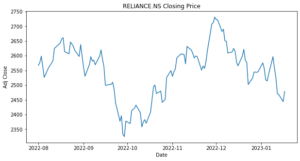

```python
plt.figure(figsize = (10,5))
sns.lineplot(data = rel_data,x='Date',y='Adj Close')
plt.title(f'{stock} Closing Price')
plt.show()
```

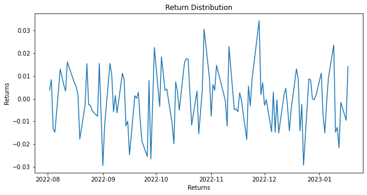

```python
plt.figure(figsize = (10,5))
sns.lineplot(data = rel_data,x='Date',y='Returns')
plt.title('Return Distribution')
plt.xlabel('Returns')
plt.show()
```

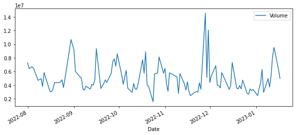

```python
rel_data['Volume'].plot(legend = True,figsize=(10,4))
```

Stock Market Data Analysis

Stock Market Analysis and Prediction is the project related to Exploratory data analysis(EDA), Data visualization and Predictive analysis using data, provided by The Investors Exchange (IEX).

We'll be answering the following questions along the way:

What was the change in price of the stock over time?

What was the daily return of the stock on average?

What was the moving average of the various stocks?

What was the correlation between different stocks' closing prices?

What was the correlation between different stocks' daily returns?

How much value do we put at risk by investing in a particular stock?

How can we attempt to predict future stock behavior?

```python
pip install pandas_datareader
```

```python
import os
import numpy as np
import pandas as pd
import matplotlib.pyplot as plt
import seaborn as sns
sns.set_style('whitegrid')
%matplotlib inline
import yfinance as yf
```

```python
## for reading stock data from The Investors Exchange (IEX)
import pandas_datareader as pdr
from datetime import datetime
```

```python
 os.environ["IEX_API_KEY"] = "sk_5bdb6470e57d4819a152b9fc1c6508ff"
```

Let's use iexfinanceThe Investors Exchange (IEX) and pandas to grab some data for some technology company stocks.

```python
tech_stocks = ['AAPL','GOOG','MSFT','AMZN']
```

```python
## SETUP END AND START TIMES FOPR DATA LOAD
end = datetime.now()
end
```

```
datetime.datetime(2023, 1, 19, 21, 48, 24, 794317)
```

```python
start = datetime(end.year - 1,end.month,end.day)
start
```

```
datetime.datetime(2022, 1, 19, 0, 0)
```

```python
age = 23

globals()['age'] = 25
print('The age is:', age)
```

```
The age is: 25
```

```python
# For loop for grabing iex finance data and setting as a dataframe
 # Set DataFrame as the Stock Ticker
for stock in tech_stocks:
      globals()[stock] = pdr.DataReader(stock,'iex',start,end, api_key=os.getenv('IEX_API_KEY'))
```

```python
AAPL.head()
```

| date | open | high | low | close | volume |
| --- | --- | --- | --- | --- | --- |
| 2022-01-19 | 170.000 | 171.08 | 165.94 | 166.23 | 94814990 |
| 2022-01-20 | 166.980 | 169.68 | 164.18 | 164.51 | 91420515 |
| 2022-01-21 | 164.415 | 166.33 | 162.30 | 162.41 | 122848858 |
| 2022-01-24 | 160.020 | 162.30 | 154.70 | 161.62 | 162706686 |
| 2022-01-25 | 158.980 | 162.76 | 157.02 | 159.78 | 115798367 |

```python
AAPL.describe()
```

|  | open | high | low | close | volume |
| --- | --- | --- | --- | --- | --- |
| count | 251.000000 | 251.000000 | 251.000000 | 251.000000 | 2.510000e+02 |
| mean | 152.882199 | 154.985945 | 150.776426 | 152.927092 | 8.729002e+07 |
| std | 13.208073 | 13.113163 | 13.234725 | 13.239496 | 2.386853e+07 |
| min | 126.010000 | 127.770000 | 124.170000 | 125.020000 | 3.519586e+07 |
| 25% | 142.617500 | 144.879500 | 140.580000 | 142.780000 | 7.092118e+07 |
| 50% | 151.450000 | 154.120000 | 149.640000 | 151.600000 | 8.250749e+07 |
| 75% | 163.970000 | 166.340000 | 162.125000 | 164.415000 | 9.603814e+07 |
| max | 178.550000 | 179.610000 | 176.700000 | 178.960000 | 1.826020e+08 |

```python
AAPL.info()
```

```
<class 'pandas.core.frame.DataFrame'>
Index: 251 entries, 2022-01-19 to 2023-01-18
Data columns (total 5 columns):
 #   Column  Non-Null Count  Dtype
---  ------  --------------  -----
 0   open    251 non-null    float64
 1   high    251 non-null    float64
 2   low     251 non-null    float64
 3   close   251 non-null    float64
 4   volume  251 non-null    int64
dtypes: float64(4), int64(1)
memory usage: 11.8+ KB
```

# Let's see a historical view of the closing price

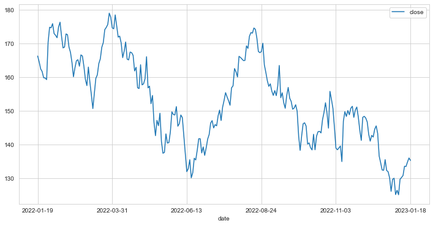

```python
AAPL['close'].plot(legend = True,figsize = (12,6))
```